# MATH 2310 Project: Is There Racial Profiling In Nashville, TN?

Nurya Temam, Andrea Lee, Justin Thoreson, David Stanko

## Introduction

Given the nation’s current state of affairs, it’s more visible now than ever how prominent racial injustice is in policing. Organized, structured records of vehicular police stops are a useful - and relevant - tool for analyzing the presence and extent of racial bias. The Stanford Open Policing Project, led by a team of interdisciplinary Stanford researchers, works to create such records by gathering and standardizing police stop data from all over the country and making it available to the public (Stanford Open Policing Project website: Findings). Although every statistical test has flaws and there could be other motives besides racial profiling, the Stanford Open Policing Project’s studies have found substantial evidence of discrimination against Black and Hispanic drivers. Stop and search rates are higher for them and hit rates are lower. The threshold test (which finds the threshold that leads officers to decide to search someone) indicated a lower threshold for Black and Hispanic drivers (Stanford Open Policing Project website: Findings). In an attempt to dissect the potential racial bias among police, we analyzed the vehicular stop rates for Nashville, Tennessee, and compared the stops through the racial demographics. The problem we want to investigate is: Is there racial profiling toward drivers by police in Nashville, Tennessee? To firmly assess the presence of racial profiling by police, the search, frisk, and hit rates, as well as the coefficient of darkness were processed.

## Methods

The data initially included both vehicular and pedestrian stops; however, since we care mostly about vehicular stops, we filtered out the pedestrian stops. The data initially included years from 2010 to 2016, and we did some analysis of all those years in the First Analysis section, but we filtered it down to only 2016 for later analysis.

We first did a broad statistical analysis of the vehicular police stops: both throughout all years from 2010 to 2016, and per year, comparing the results by race. We looked at numbers and proportions of stops by race, which are displayed in tables. We also illustrated the results using a graph. (See “First Analysis” section).

We then compared the demographics of drivers who are stopped to the demographics of Nashville as a whole, which we obtained from the US Census Bureau. This would allow us to see racial disparities in police stops: for example, whether a higher percentage of drivers of color are stopped than the percentage of people of color in Nashville’s population. We also compared the search and frisk rates (conducted by police) for each subject race. (See “Benchmark Test” section).

Next, we determined how many drivers who were searched actually had contraband, for each race. We did this by computing the “hit rate”, which is the proportion of people who were searched who actually had contraband, by race. Then, we computed the hit rates by race for each precinct in Nashville. We made graphs of minority hit rate vs. white hit rate. Then we filtered out precincts 1, 5, and 7, which had the odd result of having an Asian/Pacific Islander hit rate of 0, and recalculated the overall hit rates excluding precincts 1, 5, and 7. (See “Outcome Test” section).

Considering the search and frisk rates and the hit rates together can help determine if there is a tendency toward racial profiling.

The “Veil of Darkness” hypothesis by Grogger and Ridgeway states that police officers can better identify a driver’s race during daytime than during nighttime. Therefore, a higher percentage of drivers of color being stopped during daytime than during nighttime indicates racial profiling. We filtered the data down to a period of time during which it is dark for some parts of the year and light for other parts of the year. We used the Veil of Darkness test to find the “coefficient of darkness”, which indicates how much darkness influences whether a stopped driver will be a person of color, as opposed to time of the day. Furthermore, we considered the notion that certain precincts may police more under different times of day, which could potentially cause the data to show faulty results. To alleviate this obstacle, we took precinct hours into account, and then recalculated the coefficient of darkness. To compare the coefficient with the standard error, we calculated a 95% t confidence interval for the estimated coefficient of darkness.

The source of all our code is the tutorial provided by the Stanford Open Policing Project (https://openpolicing.stanford.edu/tutorials/), and we made slight modifications as necessary. Most of the verbal interpretations of the data are also from the tutorial, but we edited those to fit our own data. Many of the code comments are from the tutorial, but we also added our own comments.

There may be errors in parsing a few data points in some of our code, but those were very few data points compared to the size of our data set, so the parsing errors didn’t affect the overall analysis of our data.

We used the following libraries.

```r
# Libraries to include. You will probably use more libraries.
library(tidyverse)
library(lubridate)
library(magrittr)
library(dplyr)
# For veil of darkness
library(lutz)
library(suncalc)
library(splines)
```

## Results

### Data Set

We analyzed traffic stop data from Nashville.

```r
# Load the data (use read_rds for an rds file. use read.csv or read_csv for a csv file)
stops = read_csv("tn_nashville_2020_04_01.csv")
```

Additional data and fixed values we’ll be using (U.S. Census Bureau):

```r
population <- tibble(
  subject_race = c(
    "asian/pacific islander", "black", "hispanic", "other", "unknown", "white"
  ),
  num_people = c(24820, 187159, 69765, 1341, 16100, 371634)
) %>%
  mutate(subject_race = as.factor(subject_race))

center_lat <- 36.174465
center_lng <- -86.767960
```

### First Analysis

We wish to analyze the data strictly from vehicular stops. To filter out the non-vehicular stops, we ran the following code:

```r
na.omit(stops, cols = subject_race) #omits where the race may have a missing value
```

```
## # A tibble: 4,646 x 42
##    raw_row_number date  time  location   lat   lng precinct reporting_area  zone
##    <chr>          <chr> <tim> <chr>    <dbl> <dbl>    <dbl>          <dbl> <dbl>
##  1 304212         10/1~ 00:20 MELINDA~  36.1 -86.9        1           4909   121
##  2 621482         10/1~ 22:30 I 40 W ~  36.2 -86.6        5          94022   517
##  3 616665         10/1~ 18:43 BERRYWO~  36.2 -86.7        2           1411   217
##  4 616755         10/1~ 20:56 LARGO D~  36.1 -86.7        3           8705   321
##  5 1042488        10/1~ 00:05 BELL RD~  36.0 -86.6        3           8861   325
##  6 1042675        10/1~ 04:19 I 24 E ~  36.1 -86.7        3          86020   317
##  7 1043345        10/1~ 16:37 CLEVELA~  36.2 -86.8        2           1959   221
##  8 1042706        10/1~ 05:13 1005 S ~  36.3 -86.7        7           1507   711
##  9 1043447        10/1~ 17:53 3225 CR~  36.2 -86.8        7           2005   721
## 10 1043641        10/1~ 21:17 S 5TH S~  36.2 -86.8        2           1111   211
## # ... with 4,636 more rows, and 33 more variables: subject_age <dbl>,
## #   subject_race <chr>, subject_sex <chr>, officer_id_hash <chr>, type <chr>,
## #   violation <chr>, arrest_made <lgl>, citation_issued <lgl>,
## #   warning_issued <lgl>, outcome <chr>, contraband_found <lgl>,
## #   contraband_drugs <lgl>, contraband_weapons <lgl>, frisk_performed <lgl>,
## #   search_conducted <lgl>, search_person <lgl>, search_vehicle <lgl>,
## #   search_basis <chr>, reason_for_stop <chr>,
## #   vehicle_registration_state <chr>, notes <chr>,
## #   raw_verbal_warning_issued <lgl>, raw_written_warning_issued <lgl>,
## #   raw_traffic_citation_issued <lgl>, raw_misd_state_citation_issued <lgl>,
## #   raw_suspect_ethnicity <chr>, raw_driver_searched <lgl>,
## #   raw_passenger_searched <lgl>, raw_search_consent <lgl>,
## #   raw_search_arrest <lgl>, raw_search_warrant <lgl>,
## #   raw_search_inventory <lgl>, raw_search_plain_view <lgl>
```

```r
stops <- stops %>% filter(type == "vehicular") #filters out all stops with vehicular

stops %>% count(type) #counts the number of vehicular stops
```

```
## # A tibble: 1 x 2
##   type           n
##   <chr>      <int>
## 1 vehicular 664495
```

There are 664,495 vehicular stops.

With the vehicular stops filtered, the number of vehicular stops as a function of subject race are given by the following table:

```r
#Make a table of the number of stops as a function of subject race
stops %>%
  count(subject_race) %>%
  mutate(prop = n / sum(n)) # creates a new column to show the relative proportions
```

```
## # A tibble: 7 x 3
##   subject_race                n     prop
##   <chr>                   <int>    <dbl>
## 1 asian/pacific islander   9061 0.0136
## 2 black                  250573 0.377
## 3 hispanic                34435 0.0518
## 4 other                    2379 0.00358
## 5 unknown                  7506 0.0113
## 6 white                  360212 0.542
## 7 <NA>                      329 0.000495
```

The table above displays the number of stops by race and their respective proportions relative to the total number of stops. This table includes stops from every year between 2010 and 2016.

The proportion of white drivers stopped is the highest, followed by Black drivers, Hispanic drivers, Asian/Pacific Islander drivers, drivers whose race is unknown, and other drivers. We can’t conclude that this means there is no racial profiling in Nashville because there may simply be a higher number of white people in Nashville’s population. We’ll look at Nashville’s demographics later.

To get a better visual of the data, we can analyze the stops by year.

Using the following code, we can obtain the total number of stops per year from 2010 to 2016 (helped by Prof. Fischer).

```r
stops$date = mdy(stops$date) #transforms the dates
stops %>%
  mutate(year = year(date)) %>% #the column for the year
  count(year) # counts the years
```

```
## # A tibble: 7 x 2
##    year      n
##   <dbl>  <int>
## 1  2010  83989
## 2  2011  99980
## 3  2012 113705
## 4  2013 104685
## 5  2014 107120
## 6  2015  85670
## 7  2016  69346
```

The most stops were performed in 2012-2014.

We can also use a table showing the number of stops by race per year to attain a better grasp of the subject numbers.

```r
#counts the number of each race per year
stops %>% count(year = year(date), subject_race)
```

```
## # A tibble: 48 x 3
##     year subject_race               n
##    <dbl> <chr>                  <int>
##  1  2010 asian/pacific islander   974
##  2  2010 black                  31508
##  3  2010 hispanic                4023
##  4  2010 other                   1585
##  5  2010 unknown                  247
##  6  2010 white                  45652
##  7  2011 asian/pacific islander  1335
##  8  2011 black                  38408
##  9  2011 hispanic                5107
## 10  2011 other                    291
## # ... with 38 more rows
```

Stops by race per year mostly follow the trend we saw in the overall stops-per-race table: the number of white drivers stopped is the largest, followed by Black drivers, Hispanic drivers, and Asian/Pacific Islander drivers.

Now, to get a visual understanding of the data, we can use the total yearly stops to plot the yearly stops by subject race. The following code makes a plot for stops (y-axis) vs. year (x-axis) separated by race (Tutorials).

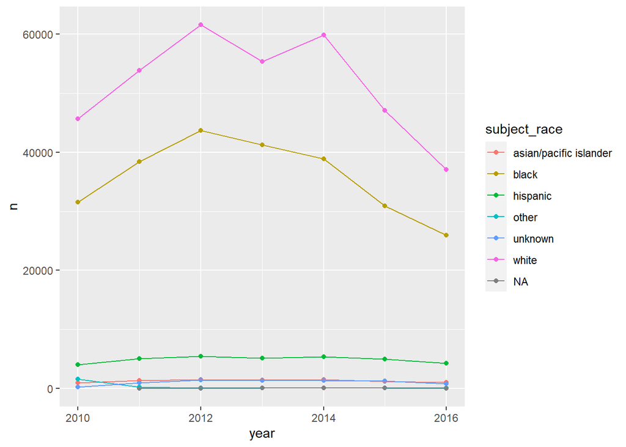

```r
stops %>%
  count(year = year(date), subject_race) %>% #counts the number of people of each race per year
  #plots the data of year by population by race
  ggplot(aes(x = year, y = n, color = subject_race)) +
  geom_point() +  #creates the points in the scatter plot
  geom_line() #creates the lines in the scatter plot
```

The graph shows that the overall number of stops has decreased from 2014 to 2016 with respect to drivers of both white drivers and minority drivers. The stops for white drivers appear to be decreasing at a faster rate compared to Black drivers. However, the rate of stops appear almost constant among the remaining subject origins.

```r
# Filters to all data that corresponds with 2016
stops <- stops %>% filter(year(date) == 2016)
```

### Benchmark Test

Notably, we saw above that, from 2010 to 2016, the number of white driver stops make up about 54.2% of the stops whilst 37.7% of the vehicular stops were with Black drivers. To get an understanding of these numbers, we need to take into account the population based on racial origin. In this case, we will focus solely on 2016 data.

#### Stop rates

The demographic of Nashville, provided by the United States Census Bureau, is shown in the following table:

```r
#Adds a column for proportion to the population data set, while still keeping the num_people column.(Source: R Documentation)
population %>%
  mutate (prop = num_people / sum(num_people))
```

```
## # A tibble: 6 x 3
##   subject_race           num_people    prop
##   <fct>                       <dbl>   <dbl>
## 1 asian/pacific islander      24820 0.0370
## 2 black                      187159 0.279
## 3 hispanic                    69765 0.104
## 4 other                        1341 0.00200
## 5 unknown                     16100 0.0240
## 6 white                      371634 0.554
```

The census provides that the Black population of Nashville is 27.9%. As we saw before, the number of vehicular stops with Black subjects are 37.7%. The vehicular stops have a higher percentage than the population, with a difference of 9.8%. To contrast this information, Nashville’s white population is 55.4%, while the number of white subject vehicular stops were 54.2%; a difference of 1.2%. These values are virtually similar, which is what one would expect when comparing stops to a particular demographic. The disparity between the Black population and the percentage of Black drivers stopped - when compared to white drivers - is evidence for racial profiling.

This code allows the two tables, number of stops and population, to join together:

```r
#Adds the subject_race column in the stops data frame to the population data frame (Source: R Documentation).
stops %>%
  count(subject_race) %>%
  left_join(
    population,
    by = "subject_race"
  ) %>%
  #n is the number of people of each racial group in the stops data frame, for the people who were stopped. num_people is the overall population of each racial group in Nashville.
  mutate(stop_rate = n / num_people) #Adds a column for stop_rate in addition to the other columns. (Source: R Documentation).
```

```
## # A tibble: 7 x 4
##   subject_race               n num_people stop_rate
##   <chr>                  <int>      <dbl>     <dbl>
## 1 asian/pacific islander  1062      24820    0.0428
## 2 black                  25973     187159    0.139
## 3 hispanic                4289      69765    0.0615
## 4 other                     89       1341    0.0664
## 5 unknown                  852      16100    0.0529
## 6 white                  37025     371634    0.0996
## 7 <NA>                      56         NA   NA
```

Based on the table above, we are shown that the Black population in Nashville has a stop rate about 1.4 times higher than the white population. The Hispanic stop rate is lower than the white stop rate, however.

#### Search & Frisk rates

Next, we will take a look at the search and frisk rate of each demographic.

```r
stops %>%
  group_by(subject_race) %>% #allows R to perform operations on each racial group (Source: R Documentation).
  summarize( #summarize() creates a data frame that shows the search rate and frisk rate by racial group (Source: R Documentation).
      #calculates search rate by race (mean number of stops when a search was conducted), omitting any search_conducted values that are "N/A") (Source: R Documentation).
      search_rate = mean(search_conducted, na.rm = T),
      #calculates frisk rate by race (mean number of stops when a search was conducted), omitting any frisk_performed values that are "N/A") (Source: R Documentation).
      frisk_rate = mean(frisk_performed, na.rm = T)
  )
```

```
## # A tibble: 7 x 3
##   subject_race           search_rate frisk_rate
##   <chr>                        <dbl>      <dbl>
## 1 asian/pacific islander      0.0169    0.00565
## 2 black                       0.0567    0.0237
## 3 hispanic                    0.0464    0.0249
## 4 other                       0.0337    0.0112
## 5 unknown                     0.0117    0.00469
## 6 white                       0.0238    0.00907
## 7 <NA>                        0.0545    0
```

It appears that by the data provided, Black drivers that were stopped were searched 2.38 times more than white drivers that were stopped. Furthermore, Hispanic drivers were searched 1.95 times more than white drivers.

Regarding the frisk rate, Black drivers were frisked 2.61 times more, and Hispanic drivers were frisked 2.75 times more than white drivers.

### Outcome Test

We wish to determine how many minority drivers who were searched actually had contraband, as opposed to white drivers. A successful search is when the police officer finds contraband. The hit rate is “what proportion of searches, by race, were successful?” (Tutorials).

We calculated the hit rates per race below:

```r
# Calculates the hit rate by race
stops %>%
  filter(search_conducted) %>% # Includes only subjects who were searched
  group_by(subject_race) %>% # Groups the subjects by race
  summarize(hit_rate = mean(contraband_found, na.rm = T) # Calculate rate of those who actually had contraband
  )
```

```
## # A tibble: 7 x 2
##   subject_race           hit_rate
##   <chr>                     <dbl>
## 1 asian/pacific islander    0.333
## 2 black                     0.238
## 3 hispanic                  0.206
## 4 other                     0
## 5 unknown                   0.3
## 6 white                     0.270
## 7 <NA>                      0
```

The hit rate for Asian/Pacific Islander drivers is the highest, and the hit rate for Black and Hispanic drivers is lower than that for white drivers. Therefore, fewer Black and Hispanic drivers who were searched actually had contraband. This would indicate racial bias toward Black and Hispanic drivers, but the rates don’t tell us about the number of drivers in each demographic who were searched. Having a small number of drivers in a certain racial demographic might make the rate higher or lower, falsely indicating or not indicating discrimination.

We computed the hit rates by race for each precinct: (The tutorial computed them for each district, but our data set has precincts).

```r
hit_rates <-
  stops %>%
  filter(search_conducted) %>%
  group_by(subject_race, precinct) %>% # Groups the hit rates by subject race, with the addition of grouping by precinct
  summarize(hit_rate = mean(contraband_found, na.rm = T))
hit_rates
```

```
## # A tibble: 47 x 3
## # Groups:   subject_race [7]
##    subject_race           precinct hit_rate
##    <chr>                     <dbl>    <dbl>
##  1 asian/pacific islander        1    0
##  2 asian/pacific islander        2    1
##  3 asian/pacific islander        3    0.667
##  4 asian/pacific islander        4    1
##  5 asian/pacific islander        5    0
##  6 asian/pacific islander        6    0.333
##  7 asian/pacific islander        8    0.333
##  8 asian/pacific islander       NA    0
##  9 black                         1    0.238
## 10 black                         2    0.205
## # ... with 37 more rows
```

Hit rates are generally the highest for Asian/Pacific Islander drivers, and they are slightly higher for white drivers than for Black drivers. For Hispanic drivers, hit rates are variable by precinct: some are higher than for white and Black drivers, and some are lower.

To analyze racial disparities by precinct, we made another table comparing the hit rates of minority drivers to those of white drivers, per precinct. We edited the code given in the tutorial to include Asian/Pacific Islander drivers.

```r
# Reshape table to show hit rates of minorities vs white drivers
hit_rates <-
  hit_rates %>%
  # Account for specific races in the hit rate data.
  filter(subject_race %in% c("black", "white", "hispanic", "asian/pacific islander")) %>%
  spread(subject_race, hit_rate, fill = 0) %>%
  rename(white_hit_rate = white) %>%
  gather(minority_race, minority_hit_rate, c("black", "hispanic", "asian/pacific islander")) %>%
  arrange(precinct) # Arrange subject race by precinct

hit_rates
```

```
## # A tibble: 27 x 4
##    precinct white_hit_rate minority_race          minority_hit_rate
##       <dbl>          <dbl> <chr>                              <dbl>
##  1        1          0.195 black                             0.238
##  2        1          0.195 hispanic                          0.143
##  3        1          0.195 asian/pacific islander            0
##  4        2          0.277 black                             0.205
##  5        2          0.277 hispanic                          0.0769
##  6        2          0.277 asian/pacific islander            1
##  7        3          0.333 black                             0.278
##  8        3          0.333 hispanic                          0.222
##  9        3          0.333 asian/pacific islander            0.667
## 10        4          0.327 black                             0.237
## # ... with 17 more rows
```

We plotted minority hit rate vs. white hit rate (Comments are from the tutorial):

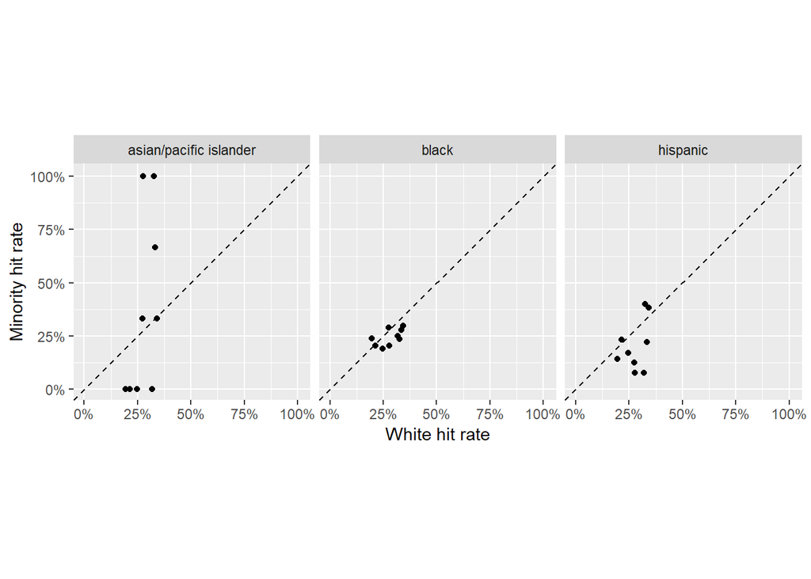

```r
# We'll use this just to make our axes' limits nice and even
# Calculates the max hit rate
max_hit_rate <-
  hit_rates %>%
  select(ends_with("hit_rate")) %>%
  max()

# Plot the white hit rates against the hit rates of other subject races
hit_rates %>%
  ggplot(aes(
    x = white_hit_rate,
    y = minority_hit_rate
  )) +
  geom_point() +
  # This sets a diagonal reference line (line of equal hit rates)
  geom_abline(slope = 1, intercept = 0, linetype = "dashed") +
  # These next few lines just make the axes pretty and even
  scale_x_continuous("White hit rate",
    limits = c(0, max_hit_rate + 0.01),
    labels = scales::percent
  ) +
  scale_y_continuous("Minority hit rate",
    limits = c(0, max_hit_rate + 0.01),
    labels = scales::percent
  ) +
  # This makes sure that 1% on the x-axis is the same as 1% on the y-axis
  coord_fixed() +
  # This allows us to compare black v. white, Hispanic v. white, and   Asian/Pacific Islander side by side, in panels
  facet_grid(. ~ minority_race)
```

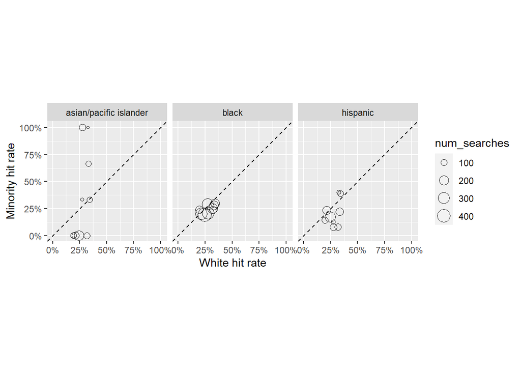

```r
# Similar to the code above, just maps the size of the points.
# Get corresponding number of searches (to size points).
# Again, for each precinct we want to know the number of white+black searches
# white+Hispanic searches, and white+Asian/Pacific islander searches.
# This requires the same spreading and gathering as our previous data-munging.
search_counts <-
  stops %>%
  filter(
    search_conducted,
    subject_race %in% c("black", "white", "hispanic", "asian/pacific islander")
  ) %>%
  count(precinct, subject_race) %>%
  spread(subject_race, n, fill = 0) %>%
  rename(num_white_searches = white) %>%
  gather(minority_race, num_minority_searches,
    c("black", "hispanic", "asian/pacific islander")
    ) %>%
  mutate(num_searches = num_minority_searches + num_white_searches) %>%
  select(precinct, minority_race, num_searches)

hit_rates %>%
  left_join(
    search_counts,
    by = c("precinct", "minority_race")
  ) %>%
  ggplot(aes(
    x = white_hit_rate,
    y = minority_hit_rate
  )) +
  geom_point(aes(size = num_searches), pch = 21) +
  geom_abline(slope = 1, intercept = 0, linetype = "dashed") +
  scale_x_continuous("White hit rate",
    limits = c(0, max_hit_rate + 0.01),
    labels = scales::percent
  ) +
  scale_y_continuous("Minority hit rate",
    limits = c(0, max_hit_rate + 0.01),
    labels = scales::percent
  ) +
  coord_fixed() +
  facet_grid(. ~ minority_race)
```

```r
  #facet_grid(cols = vars(minority_race))
```

Above, we see that the plot for Asian/Pacific Islander has data points that are virtually zero. To investigate this, we must filter to the white hit rates less than ~37.5% to rule out the precincts that generated this data.

```r
# Filters to the lowest white hit rate
hit_rates %>%
  filter(white_hit_rate <= 37.5)
```

```
## # A tibble: 27 x 4
##    precinct white_hit_rate minority_race          minority_hit_rate
##       <dbl>          <dbl> <chr>                              <dbl>
##  1        1          0.195 black                             0.238
##  2        1          0.195 hispanic                          0.143
##  3        1          0.195 asian/pacific islander            0
##  4        2          0.277 black                             0.205
##  5        2          0.277 hispanic                          0.0769
##  6        2          0.277 asian/pacific islander            1
##  7        3          0.333 black                             0.278
##  8        3          0.333 hispanic                          0.222
##  9        3          0.333 asian/pacific islander            0.667
## 10        4          0.327 black                             0.237
## # ... with 17 more rows
```

Precincts 1, 5, and 7 appear to be the culprits, having an Asian/Pacific Islander hit rate of 0. Next, let us gather the list of addresses that are recorded for stops in each of these precincts.

```r
# Find the stops precinct 1 has made
stops %>%
  filter(precinct == "1") %>%
  count(location, sort = T)
```

```
## # A tibble: 1,347 x 2
##    location                                                      n
##    <chr>                                                     <int>
##  1 CHARLOTTE PIKE & DAVIDSON DR, NASHVILLE, TN, 37209          252
##  2 6921 HWY 100, NASHVILLE, TN, 37221                          204
##  3 ERIN LN & HWY 70 S, NASHVILLE, TN, 37221                    168
##  4 CHARLOTTE PIKE & WHITE BRIDGE PIKE, NASHVILLE, TN, 37209    102
##  5 TIMBER LN & WOODLAWN DR, NASHVILLE, TN, 37215               102
##  6 CABOT DR & CHARLOTTE PIKE, NASHVILLE, TN, 37209              81
##  7 HWY 70 S & OLD HICKORY BLVD, NASHVILLE, TN, 37221            79
##  8 MM 204 0 I40 W, NASHVILLE, TN, 37209                         76
##  9 I 40 E & WHITE BRIDGE PIKE, NASHVILLE, TN, 37209             72
## 10 CHARLOTTE PIKE & OLD CHARLOTTE PIKE, NASHVILLE, TN, 37209    67
## # ... with 1,337 more rows
```

```r
# Find the stops precinct 5 has made
stops %>%
  filter(precinct == "5") %>%
  count(location, sort = T)
```

```
## # A tibble: 1,993 x 2
##    location                                                    n
##    <chr>                                                   <int>
##  1 BRILEY PKWY N & MCGAVOCK PIKE, NASHVILLE, TN, 37214       365
##  2 DELL PKWY & MURFREESBORO PIKE, NASHVILLE, TN, 37217       186
##  3 MURFREESBORO PIKE & THOMPSON PL, NASHVILLE, TN, 37217     181
##  4 BRILEY PKWY N & LEBANON PIKE, NASHVILLE, TN, 37214        176
##  5 BRILEY PKWY N & ELM HILL PIKE, NASHVILLE, TN, 37214       169
##  6 BRILEY PKWY N & TWO RIVERS PKWY, NASHVILLE, TN, 37214     118
##  7 MURFREESBORO PIKE & NASHBORO BLVD, NASHVILLE, TN, 37217   109
##  8 CENTRAL PIKE & OLD HICKORY BLVD, HERMITAGE, TN, 37076     107
##  9 816 MURFREESBORO PIKE, NASHVILLE, TN, 37217               101
## 10 FAIRFIELD AVE & HERMITAGE AVE, NASHVILLE, TN, 37210       101
## # ... with 1,983 more rows
```

```r
# Find the stops precinct 7 has made
stops %>%
  filter(precinct == "7") %>%
  count(location, sort = T)
```

```
## # A tibble: 1,132 x 2
##    location                                                     n
##    <chr>                                                    <int>
##  1 DICKERSON PIKE & DOVERSIDE DR, NASHVILLE, TN, 37207         76
##  2 BRICK CHURCH PIKE & EWING DR, NASHVILLE, TN, 37207          56
##  3 BRICK CHURCH PIKE & BRILEY PKWY W, NASHVILLE, TN, 37207     47
##  4 DICKERSON PIKE & OLD HICKORY BLVD, NASHVILLE, TN, 37207     47
##  5 BRICK CHURCH PIKE & EWING LN, NASHVILLE, TN, 37207          41
##  6 S GALLATIN PIKE & DUE WEST AVE E, MADISON, TN, 37115        38
##  7 DUE WEST AVE W & SAUNDERS AVE, MADISON, TN, 37115           35
##  8 S GALLATIN PIKE & E PALESTINE AVE, MADISON, TN, 37115       35
##  9 S GALLATIN PIKE & E OLD HICKORY BLVD, MADISON, TN, 37115    34
## 10 S GALLATIN PIKE & EMMITT AVE, MADISON, TN, 37115            34
## # ... with 1,122 more rows
```

Now we can discard precincts 1, 5, and 7 to get a better grasp of the hit rate.

```r
# Filter out the search and hit rates of drivers stopped by precincts 1, 5, 7
stops %>%
  # Finds all searches conducted excluding the three precincts
  filter(search_conducted, precinct != "1") %>% # Exclude precinct 1
  filter(search_conducted, precinct != "5") %>% # Exclude precinct 5
  filter(search_conducted, precinct != "7") %>% # Exclude precinct 7
  group_by(subject_race) %>%
  summarize(
    hit_rate = mean(contraband_found, na.rm = T)
  )
```

```
## # A tibble: 7 x 2
##   subject_race           hit_rate
##   <chr>                     <dbl>
## 1 asian/pacific islander    0.545
## 2 black                     0.258
## 3 hispanic                  0.234
## 4 other                     0
## 5 unknown                   0.25
## 6 white                     0.310
## 7 <NA>                      0
```

The results indicate that the Black hit rate is 83.34% of the white hit rate, and the Hispanic hit rate is 75.45% of the white hit rate. This indicates racial bias against Black and Hispanic drivers.

### Veil of Darkness Test

Grogger and Ridgeway proposed a hypothesis that officers “are less likely to be able to identify a driver’s race after dark than during daylight” (Tutorials). Therefore, if more Black drivers were stopped during the day, this indicates racial profiling.

Let’s look at times of the day where it was light outside during part of the year and dark outside during part of the year. This is useful because commuting patterns and driver demographics change according to what time of the day it is, but they are constant when looking at the same time of the day throughout the year.

“Sunset” is defined as “the point in time where the sun dips below the horizon”, while “dusk” is defined as “the time when the sun is six degrees below the horizon, and it is widely considered to be dark” (Tutorials). The inter-twilight period is the period between the earliest and the latest time that “dusk occurs in the year” (Tutorials).

Now we’ll find the sunset and dusk times for Nashville during the relevant years with the following code chunk:

```r
# Get timezone for Nashville
tz <- lutz::tz_lookup_coords(center_lat, center_lng, warn = F)

# Helper function that converts time from h:m:S to the specific minute of the day
time_to_minute <- function(time) {
  hour(hms(time)) * 60 + minute(hms(time))
}

# Compute sunset time for each date in our data set
# The time between sunset and dusk is the transition period from light to dark
sunset_times <-
  stops %>%
  mutate(
    lat = center_lat,
    lon = center_lng
  ) %>%
  select(date, lat, lon) %>%
  distinct() %>%
  getSunlightTimes(
    data = .,
    # Keep note of the times at sunset and dusk
    keep = c("sunset", "dusk"),
    tz = tz
  ) %>%
  mutate_at(vars("sunset", "dusk"), ~format(., "%H:%M:%S")) %>%
  mutate(
    sunset_minute = time_to_minute(sunset),
    dusk_minute = time_to_minute(dusk),
    date = ymd(str_sub(date, 1, 10))
  ) %>%
  select(date, sunset, dusk, ends_with("minute"))

sunset_times %>%
  filter(dusk == min(dusk) | dusk == max(dusk))
```

```
##         date   sunset     dusk sunset_minute dusk_minute
## 1 2016-10-01 18:31:48 18:57:25          1111        1137
## 2 2016-12-02 16:33:56 17:02:12           993        1022
```

The above times listed only show the stops that occurred between the earliest and latest sunsets of the year.This would be Nashville’s inter-twilight period.

Let’s filter out the ambiguous period between sunset and dusk, since we are unsure whether that period is light or dark.

Let’s join the sunset times to the stops data frame and filter the sunset times to only the inter-twilight period and filter out that ambiguous period. For this, we will make a data frame called vod_stops.

```r
vod_stops <-
  stops %>%
  left_join(
    sunset_times,
    by = "date"
  ) %>%
  mutate(
    minute = time_to_minute(time),
    minutes_after_dark = minute - dusk_minute,
    is_dark = minute > dusk_minute,
    min_dusk_minute = min(dusk_minute),
    max_dusk_minute = max(dusk_minute),
    # Account for multiple subject races
    is_black = subject_race == "black",
    is_hispanic = subject_race == "hispanic",
    is_api = subject_race == "asian/pacific islander",

  ) %>%
  filter(
    # Filter to get only the inter-twilight period
    minute >= min_dusk_minute,
    minute <= max_dusk_minute,
    # Remove ambiguous period between sunset and dusk
    !(minute > sunset_minute & minute < dusk_minute),
    # Compare minority and white drivers
    subject_race %in% c("black", "hispanic", "asian/pacific islander", "white")
  )
```

Let’s see the number of stops in our filtered data frame (there are 4970):

```r
# Show stops within the inter-twilight period
vod_stops %>% nrow()
```

```
## [1] 4970
```

Let’s filter the stops to the time between 5:30 and 5:45:

```r
vod_stops %>%
  filter(time > hm("17:30"), time < hm("17:45")) %>% # Filter stops within window of time
  group_by(is_dark) %>% # Discern whether the time window is dark or not
  # Summarize proportion of VoD stops by race
  summarize( prop_black = mean(is_black), prop_hispanic = mean(is_hispanic), prop_asian_pacific_islander = mean(is_api) )
```

```
## # A tibble: 2 x 4
##   is_dark prop_black prop_hispanic prop_asian_pacific_islander
##   <lgl>        <dbl>         <dbl>                       <dbl>
## 1 FALSE        0.403        0.0628                      0.0105
## 2 TRUE         0.372        0.0849                      0.0127
```

Above, we see that a higher proportion of black drivers are stopped when it is not dark outside, which raises the assumption that there is racial profiling toward Black drivers, as it is easier for cops to identify drivers when there is more daylight. However, the opposite is true for Hispanic and Asian/Pacific Islander drivers during this time window.

Let’s check this result for not only one time but for every time within the inter-twilight period. Let’s use logistic regression and find the coefficient of darkness, which measures the extent to which darkness (rather than clock time) “influences whether a stopped driver will be Black” (Tutorial).

Since we see a clearer tendency toward racial profiling among Black drivers compared to other drivers, we will prioritize the data for Black drivers.

```r
# Calculate the estimated coefficient of darkness and its standard error
# for black drivers
mod1 <- glm(
  is_black ~ is_dark + splines::ns(minute, df = 6),
  family = binomial,
  data = vod_stops
)

summary(mod1)$coefficients["is_darkTRUE", c("Estimate", "Std. Error")]
```

```
##    Estimate  Std. Error
## -0.01483182  0.07587005
```

The coefficient is negative, which means that darkness decreases “the likelihood that a stopped driver” is Black, “after adjusting for clock time” (Tutorials). Therefore, more Black drivers are stopped during the day, which would indicate racial profiling toward Black drivers.

However, we must also account for one potential question: “Is the result that we’re seeing just a product of certain districts being policed more after dark and those districts have a lower proportion of Black drivers than the districts being policed before dark?” (Tutorials). If we factor in the locations of precincts, we can make another estimate for the coefficient of darkness.

```r
# Calculate coefficient of darkness factoring in the locations of precincts
# to account for precincts that patrol differently during the day
mod2 <- glm(
  is_black ~ is_dark + splines::ns(minute, df = 6) + as.factor(precinct),
  family = binomial,
  data = vod_stops
)

summary(mod2)$coefficients["is_darkTRUE", c("Estimate", "Std. Error")]
```

```
##    Estimate  Std. Error
## -0.06907164  0.08659364
```

A 95% t confidence interval for an estimate takes approximately this form: estimate +/- 2 * (standard error).

A t confidence interval can be used when the population distribution is Normal or when the sample size is large. The number of stops in the data frame is 4970, so the sample size is large and we can use a t confidence interval.

The interpretation is: Our best estimate for the coefficient of darkness, when accounting for location, is (to 3 decimal places) -0.069. Just this number, as a point estimate, indicates racial profiling against Black drivers.

To check whether the result is mathematically robust, we tested out a few different values for the degrees of freedom (df) from 1 to 100. We tested out multiples of 10 less than or equal to 100, and integers from 1 to 10. Usually, the estimate and the standard error changed by small amounts, but the CI contained 0 every time except for df = 1. Therefore, varying the df still show the same result.

Therefore, there is insignificant evidence to support Grogger and Ridgeway’s hypothesis. The decrease in Black drivers being stopped as the sky gets dark is insignificant compared to the standard error.

## Discussion

Our intent of conducting our analysis was to find whether or not there are instances of racial profiling by police occurring in Nashville, and how great the magnitude of the profiling is itself.

We never knew that there were so many complex factors and variables that are relevant when testing for racial profiling - for example, that darkness, time of the day, and location would play a role. We thought that simply comparing the number of stops for white drivers and minority drivers would indicate the presence of racial bias, but in reality, answering this question takes far more rigorous analysis.

### Limitations of our study:

1. The benchmark test does not account for offending rates: how many people who were stopped had actually engaged in offending behavior (in driving or for other reasons), by race. If we compare the offending rates by race to the search and frisk rates by race, that would give more specific results. Furthermore, the benchmark test does not account for differences in driving behavior by race - for example, if Black drivers spend hypothetically more time on the road, then maybe they get stopped more even if police don’t engage in racial profiling (Tutorials). In the future, we can compare offending behavior by looking at the “stop reason” column and grouping stop reasons by race. By looking at the stop reasons, we can assess how severe the offenses are. Hypothetically, if we observed that minority drivers were consistently being stopped for less severe offenses than white drivers, the offending rates would be higher (more severe) for white drivers, so that would indicate racial bias.
2. The outcome test does not say anything about thresholds for searching someone by race (Tutorials). Thresholds could be based on location, not based on race (Source: in-class discussion). Certain areas could be policed under different standards, or certain precincts could have different standards as well. In the future, we can perform the threshold test as indicated in the Findings section of the Stanford Open Policing Project website, to estimate the threshold for searching drivers of each racial group. Then, we can take into account the offending rates to see if a difference in thresholds can be attributed to a difference in criminal behavior.
3. For the Veil of Darkness Test, driving behavior may change throughout the year, by race, so the test could indicate racial profiling when none occurs. Something we could do in the future is to analyze the day before and after Daylight Savings. But another question is whether lightness, as opposed to time, influences driving behavior (Tutorials).
4. Gathering reliable census data was challenging due to the multiple valid government sources categorizing and labeling demographics differently. Some sources included specific groups that were not included in others. Moreover, some sources had overlapping percentages and unknown data points. In the future, we could further our census research, then further calculate and categorize appropriate census data to fit the labels in our data set.
5. There were data entries that were empty or labeled N/A. In reality, there are more precise numbers that could be analyzed, but the lack of knowledge of the unknowns in our data set may cause the numbers to skew toward an unrealistic outcome. If we grouped the unknowns into known groups and we had enough unknowns compared to our sample size, that could drastically affect our results (Source: in-class discussion). Since there were very few unknowns in our data set compared to its large sample size, the effect of the unknowns is virtually dismissible. However, future studies would be more precise if the unknown data points were known.
6. The rates we calculated didn’t take into account the number of people in different racial groups. A small number of individuals in a category leads to uncertainty about the value of the rate. The rate would be a lot higher or lower than it would be if we had a large enough sample size. This is because larger sample sizes reduce variability and increase precision (Source: in-class discussion). In the future, we can collect more data from other reliable sources so that we can have adequate sample sizes, but the population demographics of Nashville will always be the same during the relevant years. Thus, Nashville having a small population of a certain group is not something we can change.
7. We didn’t investigate the motives for stopping. In the future, we can look at the “stop reason” column and see if there is a correlation between stop reason and race.
8. This is observational data, not an experiment. This data is not randomized and controlled. Drawing conclusions for causality from observational data can be risky and should be taken with caution (Source: in-class discussion). There is not really any way we to deal with this, but we can perform more statistical tests to gather as much evidence of racial profiling as possible.
9. People may live outside of the city that we are taking data from. So, the demographics of Nashville may not include some of the people who were stopped (Source: in-class discussion). To account for this in the future, it would be helpful to attain each driver’s Nashville residency status.

## References

U.S. Census Bureau. (n. d.). *Nashville-Davidson (balance), Tennessee.* Retrieved from https://www.census.gov/quickfacts/fact/table/nashvilledavidsonbalancetennessee/PST045219

Tutorials. (n.d.). Retrieved from https://openpolicing.stanford.edu/tutorials/

Findings. (n.d.). Retrieved from https://openpolicing.stanford.edu/findings/

E. Pierson, C. Simoiu, J. Overgoor, S. Corbett-Davies, D. Jenson, A. Shoemaker, V. Ramachandran, P. Barghouty, C. Phillips, R. Shroff, and S. Goel. “A large-scale analysis of racial disparities in police stops across the United States”. Nature Human Behaviour, Vol. 4, 2020.